# T6

## Tutorial/Lab 6

- © 2026 Samantha Sow Jin Sze. National University of Singapore. Unauthorized reproduction or distribution is prohibited.

#### Setup

1. In this exercise, we will use the Smarket (Smarket.csv) which can be downloaded from Canvas. The data records percentage returns for the S&P 500 stock index over 1,250 trading days, from the beginning of 2001 to the end of 2005. For each date, it records the returns for the previous five trading days (Lag1–Lag5), the trading volume (Volume), the percentage return on the current day (Today), and whether the market moved Up or Down (Direction).

```python
# In JupyterLab, first navigate to the directory containing College.csv
import os

# os.chdir('# Replace with your actual path')
```

We start by importing our libraries at this top level; these are all imports we have seen in previous labs.

```python
import numpy as np
import pandas as pd
import matplotlib.pyplot as plt
from matplotlib.pyplot import subplots

from sklearn.naive_bayes import GaussianNB
from sklearn.linear_model import LogisticRegression
```

a) Load the Smarket.csv dataset, display the first few rows and identify the variable names. Run Smarket.plot(y='Volume'), plot the Volume variable over time, and describe the trend in the average daily number of shares traded from 2001 to 2005.

```python
Smarket = pd.read_csv("./Smarket.csv", comment="\t", skipinitialspace=True)

# print(Smarket)

print(Smarket.head(10))
print()
print(Smarket.columns)
```

```
   Year   Lag1   Lag2   Lag3   Lag4   Lag5  Volume  Today Direction
0  2001  0.381 -0.192 -2.624 -1.055  5.010  1.1913  0.959        Up
1  2001  0.959  0.381 -0.192 -2.624 -1.055  1.2965  1.032        Up
2  2001  1.032  0.959  0.381 -0.192 -2.624  1.4112 -0.623      Down
3  2001 -0.623  1.032  0.959  0.381 -0.192  1.2760  0.614        Up
4  2001  0.614 -0.623  1.032  0.959  0.381  1.2057  0.213        Up
5  2001  0.213  0.614 -0.623  1.032  0.959  1.3491  1.392        Up
6  2001  1.392  0.213  0.614 -0.623  1.032  1.4450 -0.403      Down
7  2001 -0.403  1.392  0.213  0.614 -0.623  1.4078  0.027        Up
8  2001  0.027 -0.403  1.392  0.213  0.614  1.1640  1.303        Up
9  2001  1.303  0.027 -0.403  1.392  0.213  1.2326  0.287        Up

Index(['Year', 'Lag1', 'Lag2', 'Lag3', 'Lag4', 'Lag5', 'Volume', 'Today',
       'Direction'],
      dtype='object')
```

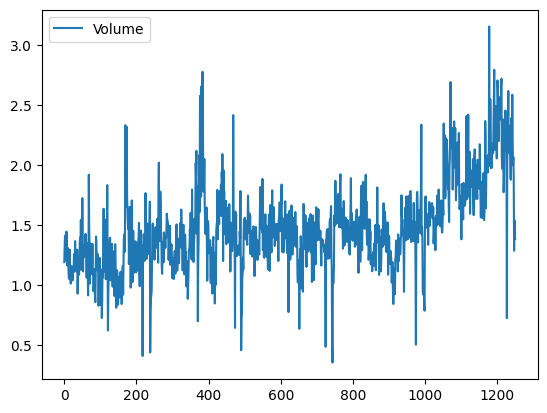

```python
Smarket.plot(y="Volume")
```

General Trend: increasing over time

### 1) Logistic Regression

Next, we will fit a logistic regression model in order to predict Direction using Lag1 through Lag5 and Volume. The smf.glm function fits generalized linear models, a class of models that includes logistic regression. The syntax of smf.glm is similar to that of smf.lm(), except that we must pass in the argument family=sm.families.Binomial() in order to tell statsmodels to run a logistic regression rather than some other type of generalized linear model.

b) To model a binary outcome for logistic regression, create a numeric response variable `Direction_response` in the `Smarket` dataset by mapping `'Up'` to 1 and `'Down'` to 0. Write the Python code to do this.

```python
Smarket["Direction_response"] = Smarket["Direction"].map({"Up": 1, "Down": 0})

print(Smarket.head())
```

```
   Year   Lag1   Lag2   Lag3   Lag4   Lag5  Volume  Today Direction  \
0  2001  0.381 -0.192 -2.624 -1.055  5.010  1.1913  0.959        Up
1  2001  0.959  0.381 -0.192 -2.624 -1.055  1.2965  1.032        Up
2  2001  1.032  0.959  0.381 -0.192 -2.624  1.4112 -0.623      Down
3  2001 -0.623  1.032  0.959  0.381 -0.192  1.2760  0.614        Up
4  2001  0.614 -0.623  1.032  0.959  0.381  1.2057  0.213        Up

   Direction_response
0                   1
1                   1
2                   0
3                   1
4                   1
```

c) Next, we will fit a logistic regression model to predict market `Direction` using `Lag1` through `Lag5` and `Volume`. Using the `statsmodels.formula.api` module, fit a logistic regression model with `Direction_response` as the response variable and `Lag1` through `Lag5` and `Volume` as predictors. Use the summary() function to print the results of the model. Comment on the output.

```python
import statsmodels.api as sm
import statsmodels.formula.api as smf

model = smf.glm(
    formula="Direction_response ~ Lag1 + Lag2 + Lag3 + Lag4 + Lag5 + Volume",
    data=Smarket,
    family=sm.families.Binomial(),  # because dependent var is 0 or 1 (binary)
)
results = model.fit()

print(results.summary())
```

```
                 Generalized Linear Model Regression Results
==============================================================================
Dep. Variable:     Direction_response   No. Observations:                 1250
Model:                            GLM   Df Residuals:                     1243
Model Family:                Binomial   Df Model:                            6
Link Function:                  Logit   Scale:                          1.0000
Method:                          IRLS   Log-Likelihood:                -863.79
Date:                Tue, 17 Mar 2026   Deviance:                       1727.6
Time:                        23:21:17   Pearson chi2:                 1.25e+03
No. Iterations:                     4   Pseudo R-squ. (CS):           0.002868
Covariance Type:            nonrobust
==============================================================================
                 coef    std err          z      P>|z|      [0.025      0.975]
------------------------------------------------------------------------------
Intercept     -0.1260      0.241     -0.523      0.601      -0.598       0.346
Lag1          -0.0731      0.050     -1.457      0.145      -0.171       0.025
Lag2          -0.0423      0.050     -0.845      0.398      -0.140       0.056
Lag3           0.0111      0.050      0.222      0.824      -0.087       0.109
Lag4           0.0094      0.050      0.187      0.851      -0.089       0.107
Lag5           0.0103      0.050      0.208      0.835      -0.087       0.107
Volume         0.1354      0.158      0.855      0.392      -0.175       0.446
==============================================================================
```

look out for:

- log odds
- coef
- z-value for log reg

d) After fitting the logistic regression model, determine whether any of the predictors (Lag1 through Lag5 and Volume) are significantly associated with the response variable `Direction_response’.

```python
print(results.params)
print(results.pvalues)
```

```
Intercept   -0.126000
Lag1        -0.073074
Lag2        -0.042301
Lag3         0.011085
Lag4         0.009359
Lag5         0.010313
Volume       0.135441
dtype: float64
Intercept    0.600700
Lag1         0.145232
Lag2         0.398352
Lag3         0.824334
Lag4         0.851445
Lag5         0.834998
Volume       0.392404
dtype: float64
```

> None of the predictor's p-value < 0.05. Hence none of the predictors are statistically significant at the 5% level

e) Interpret the coefficient of Lag1 in the logistic regression model. What does its coefficient estimate mean in terms of log-odds?

> The coefficient of Lag1 is −0.0731.

> In terms of log-odds: The log-odds of the market going Up decrease by 0.0731 for every 1 percentage point increase in Lag1 (yesterday's return), holding all other variables constant.

> The odds ratio for Lag1 = e^(−0.0731) ≈ 0.9296

> In terms of odds: For every 1 percentage point increase in yesterday's return (Lag1), the odds of the market going Up today are multiplied by 0.9296 — i.e., the odds decrease by about 7%, holding all other variables constant.

> Since Lag1 is not statistically significant, the effect is not meaningful and may just be noise

f) Using the fitted logistic regression model, calculate the odds ratio associated with the variable Volume. Interpret what this odds ratio implies about the relationship between the daily trading volume and the likelihood that the market goes Up

```python
print("Odds of Volume: {:.3f} : 1".format(np.exp(0.1354)))

print("% Change in Odds: {:.2f}".format((np.exp(0.1354) - 1) * 100))
```

```
Odds of Volume: 1.145 : 1
% Change in Odds: 14.50
```

> An odds ratio change of 1.145 means that for each additional billion shares traded, the odds will go up by 1.145 times or 14.5%.

> Higher daily trading volume is associated with slightly higher odds of an Up day. However it is not statistically significant, so cannot conclude the volume affects market direction

g) Using the fitted logistic regression model, predict the probability that the market goes Up for each observation. Then, convert these probabilities into predicted class labels (0 for 'Down' and 1 for 'Up') using a threshold of 0.5. Write Python code to perform these steps and print the resulting predicted class labels, y_pred_class.

```python
# Predict probabilities
y_pred_prob = results.predict(Smarket)
Smarket["y_pred_prob"] = results.predict(Smarket)

# Convert probabilities to predicted class labels (0 or 1)
# 0.5 set as threshold, <0.5 is 0, >=0.5 is 1
y_pred_class = (y_pred_prob >= 0.5).astype(int)
print(y_pred_class)

Smarket["y_pred_class"] = (y_pred_prob >= 0.5).astype(int)

Smarket.head(10)
```

```
0       1
1       0
2       0
3       1
4       1
       ..
1245    1
1246    1
1247    1
1248    1
1249    1
Length: 1250, dtype: int64
```

|  | Year | Lag1 | Lag2 | Lag3 | Lag4 | Lag5 | Volume | Today | Direction | Direction_response | y_pred_prob | y_pred_class |
| --- | --- | --- | --- | --- | --- | --- | --- | --- | --- | --- | --- | --- |
| 0 | 2001 | 0.381 | -0.192 | -2.624 | -1.055 | 5.010 | 1.1913 | 0.959 | Up | 1 | 0.507084 | 1 |
| 1 | 2001 | 0.959 | 0.381 | -0.192 | -2.624 | -1.055 | 1.2965 | 1.032 | Up | 1 | 0.481468 | 0 |
| 2 | 2001 | 1.032 | 0.959 | 0.381 | -0.192 | -2.624 | 1.4112 | -0.623 | Down | 0 | 0.481139 | 0 |
| 3 | 2001 | -0.623 | 1.032 | 0.959 | 0.381 | -0.192 | 1.2760 | 0.614 | Up | 1 | 0.515222 | 1 |
| 4 | 2001 | 0.614 | -0.623 | 1.032 | 0.959 | 0.381 | 1.2057 | 0.213 | Up | 1 | 0.510781 | 1 |
| 5 | 2001 | 0.213 | 0.614 | -0.623 | 1.032 | 0.959 | 1.3491 | 1.392 | Up | 1 | 0.506956 | 1 |
| 6 | 2001 | 1.392 | 0.213 | 0.614 | -0.623 | 1.032 | 1.4450 | -0.403 | Down | 0 | 0.492651 | 0 |
| 7 | 2001 | -0.403 | 1.392 | 0.213 | 0.614 | -0.623 | 1.4078 | 0.027 | Up | 1 | 0.509229 | 1 |
| 8 | 2001 | 0.027 | -0.403 | 1.392 | 0.213 | 0.614 | 1.1640 | 1.303 | Up | 1 | 0.517614 | 1 |
| 9 | 2001 | 1.303 | 0.027 | -0.403 | 1.392 | 0.213 | 1.2326 | 0.287 | Up | 1 | 0.488838 | 0 |

h) Import the library ‘from sklearn import metrics’ and, using the numeric response variable `Direction_response` and the predicted class labels stored in `y_pred_class` compute the confusion matrix to evaluate the performance of your logistic regression model.

```python
from sklearn import metrics

confusion = metrics.confusion_matrix(Smarket["Direction_response"], y_pred_class)

# Define label order to ensure mapping
class_names = ["Down", "Up"]

# Create a DF for better display w labels
cm_df = pd.DataFrame(
    confusion,
    index=[f"Actual: {cls}" for cls in class_names],
    columns=[f"Predicted: {cls}" for cls in class_names],
)

print(cm_df)
```

```
              Predicted: Down  Predicted: Up
Actual: Down              145            457
Actual: Up                141            507
```

i) Compute the metrics, accuracy, precision, specificity to evaluate the performance of your logistic regression model.

```python
from sklearn.metrics import classification_report

target_names = ["Down", "Up"]

print(
    classification_report(
        Smarket["Direction_response"], y_pred_class, target_names=target_names, digits=4
    )
)
```

```
              precision    recall  f1-score   support

        Down     0.5070    0.2409    0.3266       602
          Up     0.5259    0.7824    0.6290       648

    accuracy                         0.5216      1250
   macro avg     0.5165    0.5116    0.4778      1250
weighted avg     0.5168    0.5216    0.4834      1250
```

### 2) Held out data

The logistic regression model appears slightly better than random guessing, but this is misleading because it was both trained and tested on the same 1,250 observations. This training error is overly optimistic and underestimates the true test error. To properly evaluate the model, we must train it on one portion of the data and test it on another.

a) To do this, create a Boolean vector, train that selects observations from 2001–2004 and mark rows before 2005 as ‘True’. Use this vector with the loc method to extract the training data. Then use ~train to select the held-out test data containing the 252 observations from 2005.

```python
train = Smarket.Year < 2005
print(train)

train_data = Smarket.loc[train]
test_data = Smarket.loc[~train]
test_data.shape
```

```
0        True
1        True
2        True
3        True
4        True
        ...
1245    False
1246    False
1247    False
1248    False
1249    False
Name: Year, Length: 1250, dtype: bool
```

```
(252, 12)
```

b) Using only the training data, observations from dates before 2005, fit a logistic regression model to predict whether the stock market will go up.

```python
model_train = smf.glm(
    formula="Direction_response ~ Lag1 + Lag2 + Lag3 + Lag4 + Lag5 + Volume",
    data=train_data,
    family=sm.families.Binomial(),  # because dependent var is 0 or 1 (binary)
)
results_train = model_train.fit()
print(results_train.summary())
```

```
                 Generalized Linear Model Regression Results
==============================================================================
Dep. Variable:     Direction_response   No. Observations:                  998
Model:                            GLM   Df Residuals:                      991
Model Family:                Binomial   Df Model:                            6
Link Function:                  Logit   Scale:                          1.0000
Method:                          IRLS   Log-Likelihood:                -690.55
Date:                Tue, 17 Mar 2026   Deviance:                       1381.1
Time:                        23:21:17   Pearson chi2:                     998.
No. Iterations:                     4   Pseudo R-squ. (CS):           0.002162
Covariance Type:            nonrobust
==============================================================================
                 coef    std err          z      P>|z|      [0.025      0.975]
------------------------------------------------------------------------------
Intercept      0.1912      0.334      0.573      0.567      -0.463       0.845
Lag1          -0.0542      0.052     -1.046      0.295      -0.156       0.047
Lag2          -0.0458      0.052     -0.884      0.377      -0.147       0.056
Lag3           0.0072      0.052      0.139      0.889      -0.094       0.108
Lag4           0.0064      0.052      0.125      0.901      -0.095       0.108
Lag5          -0.0042      0.051     -0.083      0.934      -0.104       0.096
Volume        -0.1163      0.240     -0.485      0.628      -0.586       0.353
==============================================================================
```

c) Using the fitted model, calculate the predicted probabilities that the stock market will go up for each day in the test data, held-out data from 2005. Remember that the model is trained only on pre-2005 observations, and the held-out data should be used exclusively for testing.

```python
probs = results_train.predict(exog=test_data)

print(probs)
```

```
998     0.528220
999     0.515669
1000    0.522652
1001    0.513854
1002    0.498334
          ...
1245    0.483637
1246    0.506048
1247    0.516658
1248    0.516124
1249    0.508072
Length: 252, dtype: float64
```

d) Threshold the fitted probabilities at 0.5 to generate predicted class for the held-out test data. Assign 1 (“Up”) if the predicted probability ≥ 0.5 and assign 0( “Down”) if the predicted probability <0.5. This will give you a predicted class for each observation in the 2005 test set.

```python
# convert to predicted class (0 or 1) with boolean conversion
y_pred_class_test = (probs >= 0.5).astype(int)
```

e) Extract the Direction_response column from Smarket and create the training and held-out test labels.

```python
labels_train = train_data["Direction_response"]
labels_test = test_data["Direction_response"]
```

f) Compute the confusion matrix for the predicted labels versus the actual labels in the held-out test set. Using the confusion matrix, compute the metrics, accuracy, precision, specificity comment on the performance of the logistic regression model.

```python
confusion_test = metrics.confusion_matrix(
    test_data["Direction_response"], y_pred_class_test
)
print(confusion_test)
```

```
[[77 34]
 [97 44]]
```

```python
target_names_test = ["Up", "Down"]

print(
    classification_report(
        test_data["Direction_response"],
        y_pred_class_test,
        target_names=target_names_test,
    )
)
```

```
              precision    recall  f1-score   support

          Up       0.44      0.69      0.54       111
        Down       0.56      0.31      0.40       141

    accuracy                           0.48       252
   macro avg       0.50      0.50      0.47       252
weighted avg       0.51      0.48      0.46       252
```

g) Refit the logistic regression model using only the predictors `Lag1` and `Lag2`, which showed the highest predictive power in the original model. How does removing the other less useful predictors affect the model’s performance on the held-out 2005 test data? Compare the results to the original model.

```python
# model_train = smf.glm(
#     formula="Direction_response ~ Lag1 + Lag2 + Lag3 + Lag4 + Lag5 + Volume",
#     data=train_data,
#     family=sm.families.Binomial(),  # because dependent var is 0 or 1 (binary)
# )

model_g = smf.glm(
    formula="Direction_response ~ Lag1 + Lag2",
    data=train_data,
    family=sm.families.Binomial(),  # because dependent var is 0 or 1 (binary)
)
results_g = model_g.fit()
probs_g = results_g.predict(exog=test_data)

print(results_g.summary())

# print(probs_g)

y_pred_class_new = (probs_g >= 0.5).astype(int)

# print(y_pred_class_new)

confusion_test_g = metrics.confusion_matrix(
    test_data["Direction_response"], y_pred_class_new
)
print(confusion_test_g)
```

```
                 Generalized Linear Model Regression Results
==============================================================================
Dep. Variable:     Direction_response   No. Observations:                  998
Model:                            GLM   Df Residuals:                      995
Model Family:                Binomial   Df Model:                            2
Link Function:                  Logit   Scale:                          1.0000
Method:                          IRLS   Log-Likelihood:                -690.70
Date:                Tue, 17 Mar 2026   Deviance:                       1381.4
Time:                        23:21:17   Pearson chi2:                     998.
No. Iterations:                     4   Pseudo R-squ. (CS):           0.001865
Covariance Type:            nonrobust
==============================================================================
                 coef    std err          z      P>|z|      [0.025      0.975]
------------------------------------------------------------------------------
Intercept      0.0322      0.063      0.508      0.611      -0.092       0.156
Lag1          -0.0556      0.052     -1.076      0.282      -0.157       0.046
Lag2          -0.0445      0.052     -0.861      0.389      -0.146       0.057
==============================================================================
[[ 35  76]
 [ 35 106]]
```

h) Given Lag1 = -0.5, Lag2 = 0.3, calculate the predicted probability that Direction_response = Up.

```python
# new_obs = pd.DataFrame({"Lag1": [-0.5], "Lag2": [0.3]})
# pred_prob = results_g.predict(exog=new_obs)
# print(f"Predicted probability of Up: {pred_prob.values[0]:.4f}")

intercept = 0.0322
coef_lag1 = -0.0556
coef_lag2 = -0.0445

lag1 = -0.5
lag2 = 0.3

logit_p = intercept + coef_lag1 * lag1 + coef_lag2 * lag2

prob_up = 1 / (1 + np.exp(-logit_p))

print(f"Predicted prob of Direction_response = up: {prob_up:.4f}")
```

```
Predicted prob of Direction_response = up: 0.5117
```